# Stomach vs. Liver Transcriptomic Analysis

BINF694 - Interim Report

April 22, 2025

# Introduction

The human body is comprised of diverse organs with specialized functions that are ultimately reflected in their gene expression profiles. Of these, the liver and stomach represent two distinct but complementary filtering systems that process what enters the body. Transcriptomic analysis allows us to see these underling specialized functions at the genomic level.

The liver serves as the body’s primary detoxification center, filtering blood. It synthesizes essential proteins including albumin and clotting factors, and maintains glucose homeostasis through glycogen storage and gluconeogenesis (Rui, 2014). These functions require coordinated expression of genes encoding cytochrome P450 enzymes, transporters like ABCC2, and serum proteins such as alpha-1 antitrypsin (AAT).

In contrast, the stomach functions as the initial filtering station for ingested materials. Its specialized epithelium includes parietal cells that secrete hydrochloric acid (HCl) via H+/K+-ATPase pumps (ATP4A, ATP4B), chief cells producing pepsinogen, and mucus-secreting cells that protect the stomach lining (Mills & Shivdasani, 2011). This acidic environment serves as both a chemical barrier against pathogens and initiates protein digestion.

This hypothesizes that the liver and stomach will show differentially expressed gene patterns reflecting their specialized filtering functions, with the liver expressing higher levels of detoxification and metabolic pathway genes, while the stomach will show elevated expression of genes related to acid production, mucus secretion, and initial digestive processes. Through RNA-sequencing analysis of three biological replicates from each tissue, we aim to characterize these distinct transcriptomic signatures and identify the key molecular pathways that distinguish these filtering organs.

## Hypothesis

The liver and stomach will show differentially expressed gene patterns reflecting their specialized filtering functions. The liver will express higher levels of detoxification and metabolic pathway genes; while the stomach will show elevated expression of genes related to acid production, mucus secretion, and initial digestive processes.

# Methods

Claude 3.7 Sonnet[https://claude.ai/share/5142901c-bf60-4d6b-a944-a95c549ac000]

## Qualitiy Control

The first step was to perform quality control analysis on the 6 tissue samples using FastQC. The selected samples were analyzed using version 0.11.9 of FastQC. Quality metrics including per base sequence quality, per sequence quality scores, sequence duplication levels, adapter content, and k-mer content were evaluated.

#### Liver Tissue Analysis

Overall the three liver samples analyzed expressed similar results. There were no concerns with the results from samples a and c, however, with sample d there is some concern with a substantial proportion of bases had quality scores below 28, which led to higher filtering rates during trimming.

## Trimming

Trimming Results | Table 1

| sample | Remaining.Percentage |
| --- | --- |
| liver_a | 90.50% |
| liver_c | 91.40% |
| liver_d | 79.70% |
| stomach_a | 90.70% |
| stomach_3a | 87.90% |
| stomach_3b | 81.30% |

After it was determined that we can proceed with further analysis of the provided samples, FastQC was utilized to trim the samples. The samples were filtered on a minimum read length of 40 and a quality score of 28. This will allow us to retain the sequences meeting our quality threshold.

As expected, liver_d and stomach_3b had the highest proportion of sequences filtered out during this step, consistent with their lower initial quality metrics.

## Mapping

Mapping Results | Table 2

| sample | mapped_reads_percent | missmatch_rate | mapped_multi_location_percent |
| --- | --- | --- | --- |
| liver_a | 92.37% | 0.14% | 6.90% |
| liver_c | 93.86% | 0.13% | 5.49% |
| liver_d | 93.14% | 0.22% | 6.22% |
| stomach_a | 90.05% | 0.27% | 6.99% |
| stomach_3a | 88.25% | 0.29% | 9.06% |
| stomach_3b | 77.52% | 0.28% | 21.08% |

Using the filtered sequences, STAR version 2.7.11b was utilized to align the sequences in the genome. The results from the mapping were not concerning. Overall, there was a higher mismatch rate for the stomach tissue samples. The may also be some quality issues with stomach_3b as the mapping rate of about 77.5% is pretty low. This may indicate some contamination in the sample as well as the multi mapping rate was much higher than the other tissue samples.

SAMtools version 1.19.2 was then used to create the .bam files that will be used for counting.

## Genome Visulization

Integrative Genomics Viewer (IGV) version 2.8.0 was used to visualize read alignments for genes of interest, allowing for inspection of exon coverage patterns and verification of expression differences between liver and stomach tissues.

## Read Counting

HTSeq version 0.11.2 was used to count the 6 sorted and aligned .bam file provided by trimming and mapping.

**Paramaters:**

```
mode intersection-nonempty
stranded no
format bam
type exon
idattr gene_name
```

## Differential Expression Analysis

Differential expression analysis was performed using DESeq2 version 1.38.0 in R version 4.2.0. 1. Via a created count matrix from the six tissue counts, a DESeqDataSet object was created 2. Low-count genes (those with fewer than 10 reads across all samples) were filtered out 3. Results were ordered by adjusted p-value and exported to a tab-delimited file

## Understanding Sample Relationships

Additionally, selected marker genes from various research publications were analyzed separately and visualized in a heatmap with row-based scaling to highlight expression patterns.

## Enrichment Analysis

**DAVID (Database for Annotation, Visualization and Integrated Discovery) version 6.8**

- Functional annotation
- Ontology
  - Biological process
  - molecular function
  - cellular component
- KEGG pathways

**Enrichr**

- GO Biological
- KEGG 2021 Human
- WikiPathways 2023 Human

# Results

## Sample Relationship

The Principle component analysis (PCA) plot further confirms the distinct transcriptomic profiles between liver and stomach samples in your analysis. This PCA plot provides a dimensionality reduction visualization of your RNA-seq data after variance stabilizing transformation.

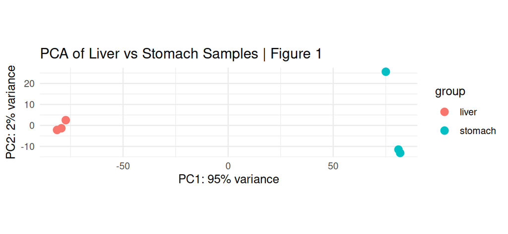

The extreme separation along PC1 (which captures 95% of variance) provides enough evidence that the profiles of liver and stomach are fundamentally different, supporting your hypothesis about their distinct filtering functions. This is consistent with the expected biological differences between these organs, with liver specialized for blood filtration/detoxification and stomach for food processing. The large proportion of variance explained by PC1 suggests there are strongly differentially expressed genes between these tissues, which should provide rich material for pathway and functional analysis.

Next we will use a heatmap to visualize the clustering of samples by tissue type.

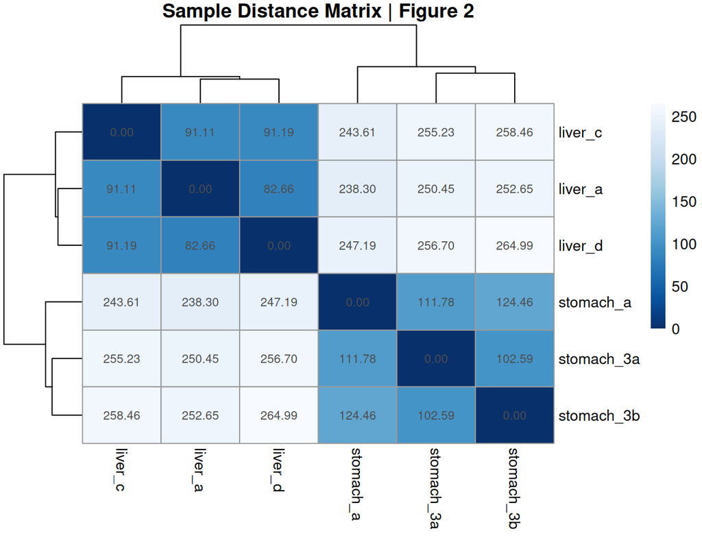

The heatmap shows a hierarchical clustering of your six samples based on their gene expression profiles after variance stabilizing transformation. The numerical values represent Euclidean distances between samples, with darker blue indicating greater similarity (smaller distance).

Observations to note:

- There are two defined clusters corresponding to each tissue type.
- With-in the both clusters for liver and stomach there is a high similarity to each other respectively.
- Overall, the distances between liver and stomach sample are much larger, indicating substantial differences between tissue type

This visualization strongly supports the experimental design. The clear separation between liver and stomach samples confirms that tissue-specific gene expression patterns are the dominant source of variation in your dataset, which aligns with the hypothesis about the distinct filtering functions of these organs.

## Differential Expression Analysis

Looking specifically into gene expression in terms of the different tissue types. The DESeq2 analysis was utilized to create a heatmap that shows the top 50 differentially expressed genes between liver and stomach tissues. The heatmap displays normalized expression values for the 50 most significantly differentially expressed genes.

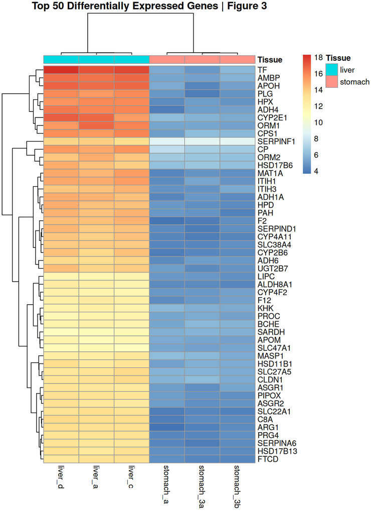

Pretty much all of the top genes were more directly associated with liver specific functions. Some of the liver functions highlighted by these genes were detoxification enzymes, lipid metabolism, and metabolic enzymes.

The next step was to determine the top genes differencially expressed for each tissue type. The goal here is to determine if there are any gene similarly expressed genes based on the top genes for each tissue. This will help shed more light on the top expressed genes from stomach tissue samples because overall there was less differentially expressed genes for this type.

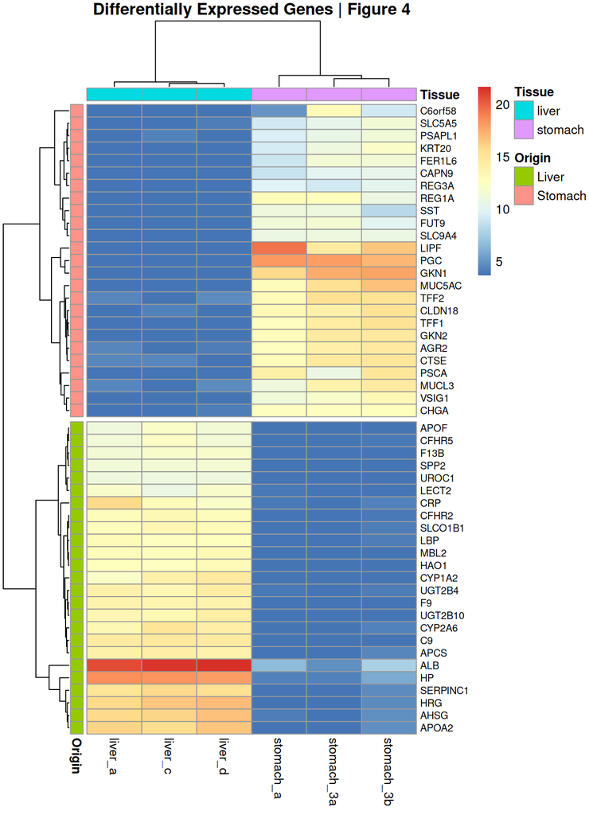

**Liver-Specific Genes:** ALB: Albumin, the most abundant protein in blood plasma, produced almost exclusively by the liver  
SERPINC1: Antithrombin, a serine protease inhibitor that regulates blood coagulation HP, HRG, AHSG, APOA2

Using these genes one last heatmap was created to see if there is any expression between even more specific genes.

[figure not shown]

# – Outline –

# Abstract

# Introduction

## Sample Selection

## Hypothesis

# Methods

## Qualitiy Analysis

## Trimming

## Mapping

## Counting

## Statistical Analysis

### Heatmap

### PCA

### Gene Heatmap

### Pathway / GO enrichment

# Results

# Discussion

# Conclusion

# References

Gattu, A. K., Swenson, E. S., Iwakiri, Y., Samuel, V. T., Troiano, N., Berry, R., Church, C. D., Rodeheffer, M. S., Carpenter, T. O., & Chung, C. (2013). Determination of mesenchymal stem cell fate by pigment epithelium-derived factor (PEDF) results in increased adiposity and reduced bone mineral content. FASEB journal : official publication of the Federation of American Societies for Experimental Biology, 27(11), 4384–4394. https://doi.org/10.1096/fj.13-232900

Mills, J. C., & Shivdasani, R. A. (2011). Gastric epithelial stem cells. Gastroenterology, 140(2), 412–424. https://doi.org/10.1053/j.gastro.2010.12.001

Rui L. (2014). Energy metabolism in the liver. Comprehensive Physiology, 4(1), 177–197. https://doi.org/10.1002/cphy.c130024